# task 10 - 1

Paulius Kostickis

Monday, April 18, 2016

1. For this exercise, use the price of a dozen eggs in the United States from 1900–1993 (data set eggs). Experiment with the various options in the holt() function to see how much the forecasts change with damped or exponential trend. Also try changing the parameter values for and to see how they affect the forecasts. Try to develop an intuition of what each parameter and argument is doing to the forecasts. [Hint: use h=100 when calling holt() so you can clearly see the differences between the various options when plotting the forecasts.] Which model gives the best RMSE? Do the residuals from the best model look like white noise?

Duomenyse matomas trendas ir ciklai:

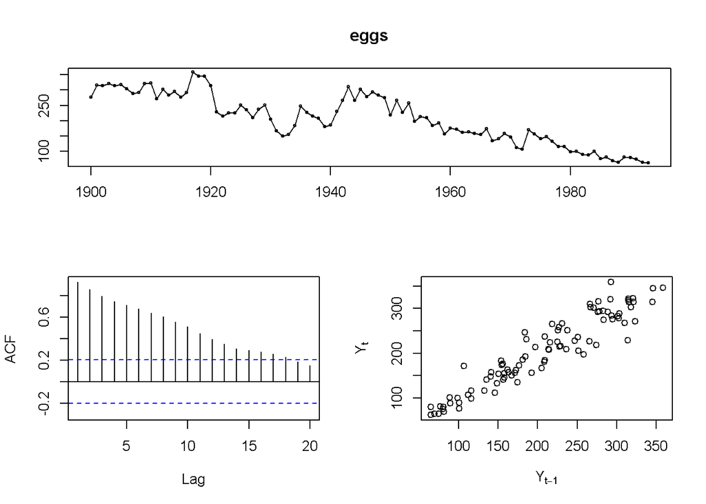

```r
tsdisplay(eggs, plot.type="scatter")
```

### Holt tiesinis glodinimas su trendu

Alfa ir betos buvo parinktos pačios programos:

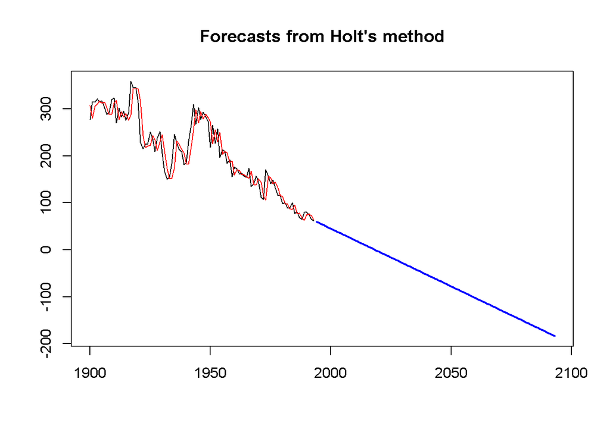

```r
fit1=holt(eggs,h=100,initial="optimal",exponential=F,damped=F)
plot(fit1, plot.conf=FALSE)
lines(fitted(fit1), col="red")
```

```r
x1=fit1$model        # alfa = 0.82  beta = 0.0001
```

Pakeisime parametrus patys:

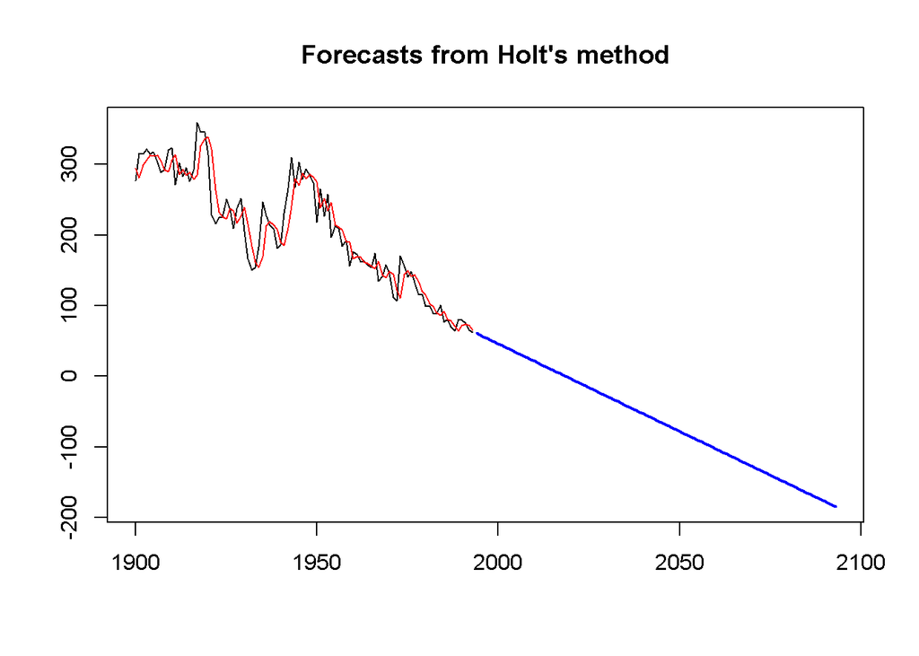

```r
fit12=holt(eggs,alpha=0.6, beta = 0.0001, h=100,exponential=F,damped=F)
plot(fit12, plot.conf=FALSE)
lines(fitted(fit12), col="red")
```

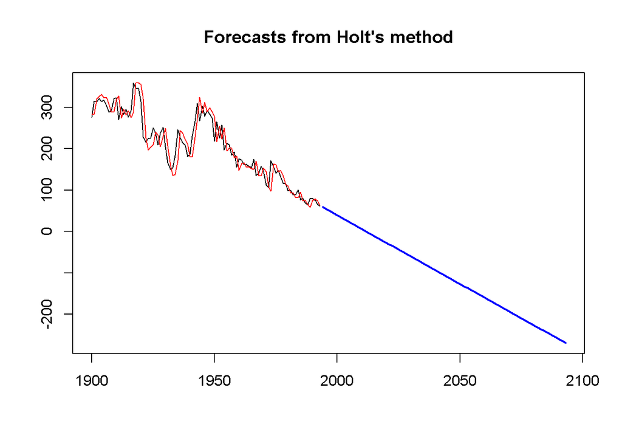

```r
x2=fit12$model       # alfa = 0.6  beta = 0.0001


fit13=holt(eggs,alpha=0.82, beta=0.2, h=100,exponential=F,damped=F)
plot(fit13, plot.conf=FALSE)
lines(fitted(fit13), col="red")
```

```r
x3=fit13$model       # alfa = 0.82  beta = 0.2
```

Matome, sumažinus alfą nuo optimalių parametrų, glodinti duomenys pasislenka daugiau į dešinę nuo duomenų (daugiau atsilieka). O padidinus beta nuo optimalių parametrų, glodinti duomenys stipriau šokinėja aplink duomenis. Tai galima buvo numatyti žvelgiant iš teorinės pusės, nes sumažinus alfą, didės preitų duomenų įtaka glodinimui. O padidinus betą, mažės glodnumas, atsiras stipresnis šokinėjimas, dėl didesnės sezoniškumo daromos įtakos glodinimui.

### Holt eksponentinis glodinimas su trendu

Alfa ir betos buvo parinktos pačios programos:

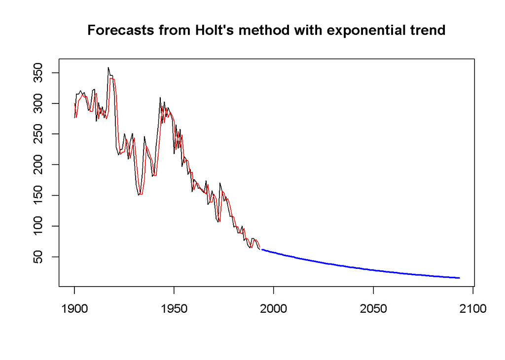

```r
fit2=holt(eggs,h=100,initial="optimal",exponential=T,damped=F)
plot(fit2, plot.conf=FALSE)
lines(fitted(fit2), col="red")
```

```r
x4=fit2$model        # alfa = 0.82  beta = 0.0001
```

Pakeisime parametrus patys:

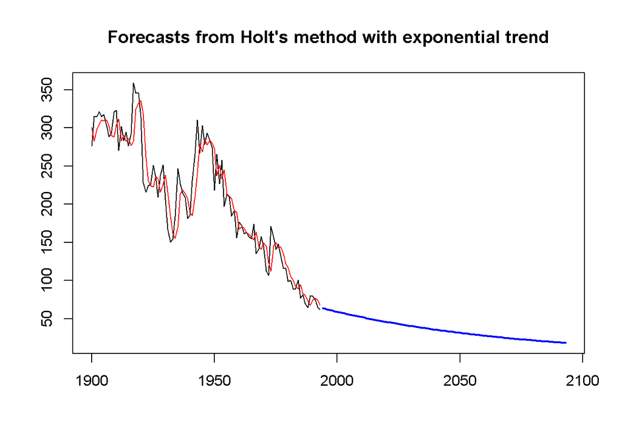

```r
fit22=holt(eggs,alpha=0.6, h=100,exponential=T,damped=F)
plot(fit22, plot.conf=FALSE)
lines(fitted(fit22), col="red")
```

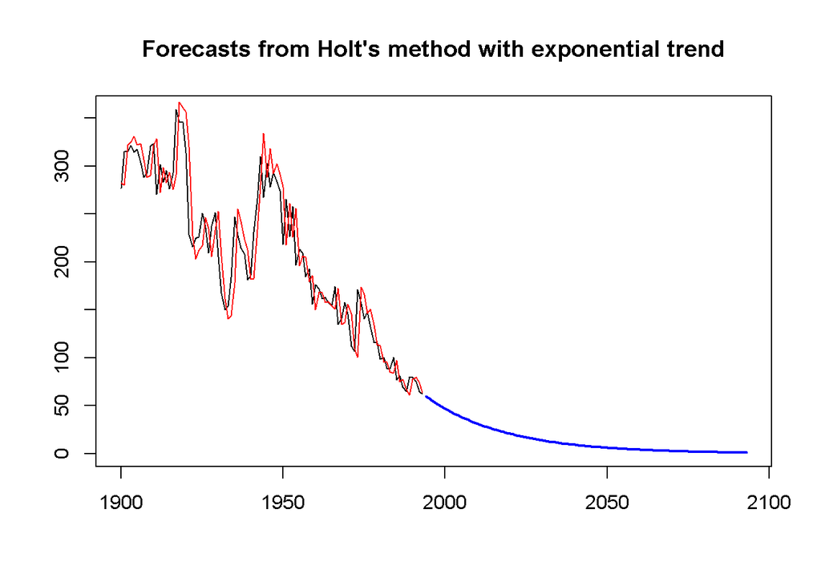

```r
x5=fit22$model       # alfa = 0.6  beta = 0.0001


fit23=holt(eggs,beta=0.2, h=100,exponential=T,damped=F)
plot(fit23, plot.conf=FALSE)
lines(fitted(fit23), col="red")
```

```r
x6=fit23$model       # alfa = 0.82  beta = 0.2
```

Matome, sumažinus alfą nuo optimalių parametrų, duomenys tampa glodesni. O padidinus beta nuo optimalių parametrų, glodinti duomenys stipriau šokinėja aplink duomenis.

### Holt slopinamas glodinimas su trendu

Alfa,betos ir fi buvo parinktos pačios programos, eksponentiniui ir tiesiniu atvejais:

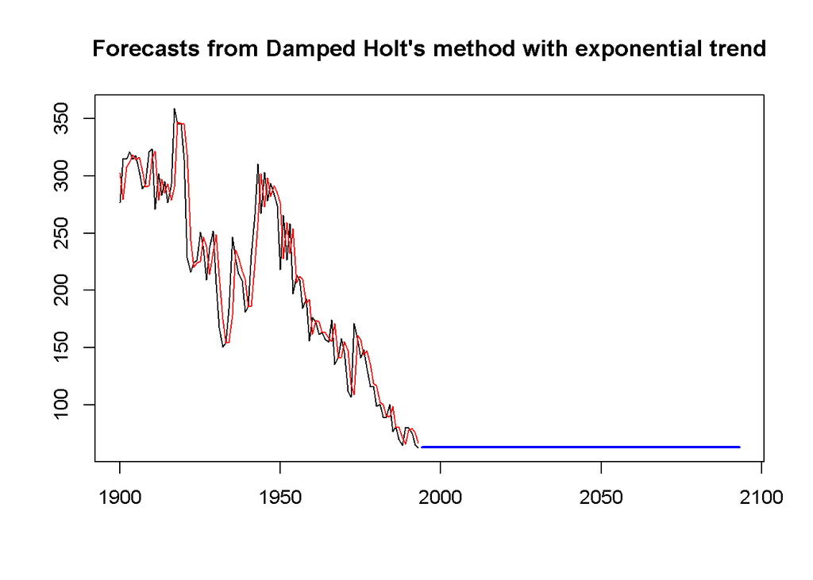

```r
fit3=holt(eggs,h=100,initial="optimal",exponential=T,damped=T)
plot(fit3, plot.conf=FALSE)
lines(fitted(fit3), col="red")
```

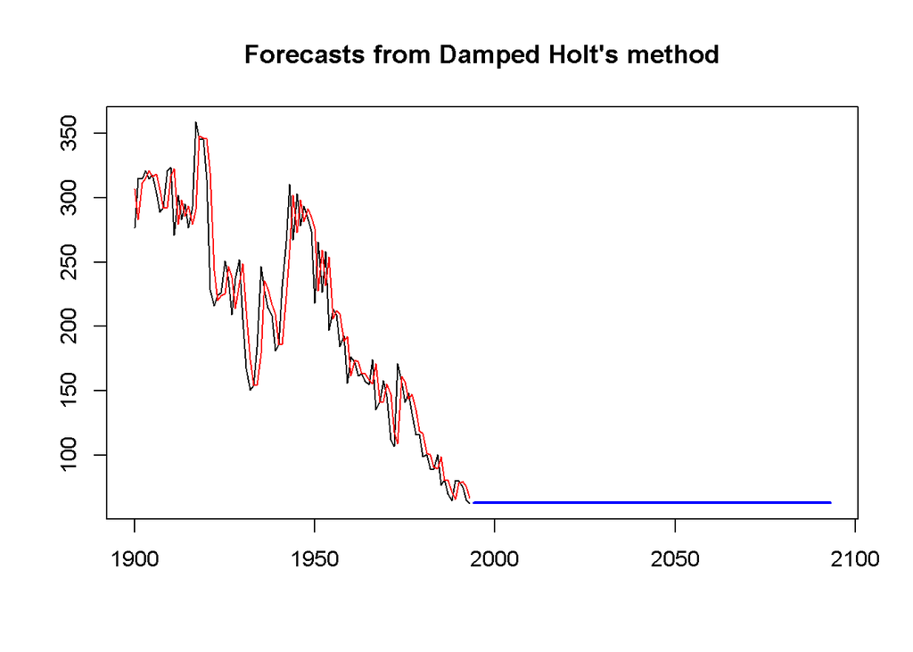

```r
x7=fit3$model        # alfa = 0.83  beta = 0.0001,  fi = 0.89

fit4=holt(eggs,h=100,initial="optimal",exponential=F,damped=T)
plot(fit4, plot.conf=FALSE)
lines(fitted(fit4), col="red")
```

```r
x8=fit4$model        # alfa = 0.84  beta = 0.0001,  fi = 0.8
```

Gaunama beveik identiški grafikai, kai naudajami otimalūs parametrai slopinamu atveju tiek eksponentiniui ir tiek tiesiniu atvejais.

### Prognozių lyginimas:

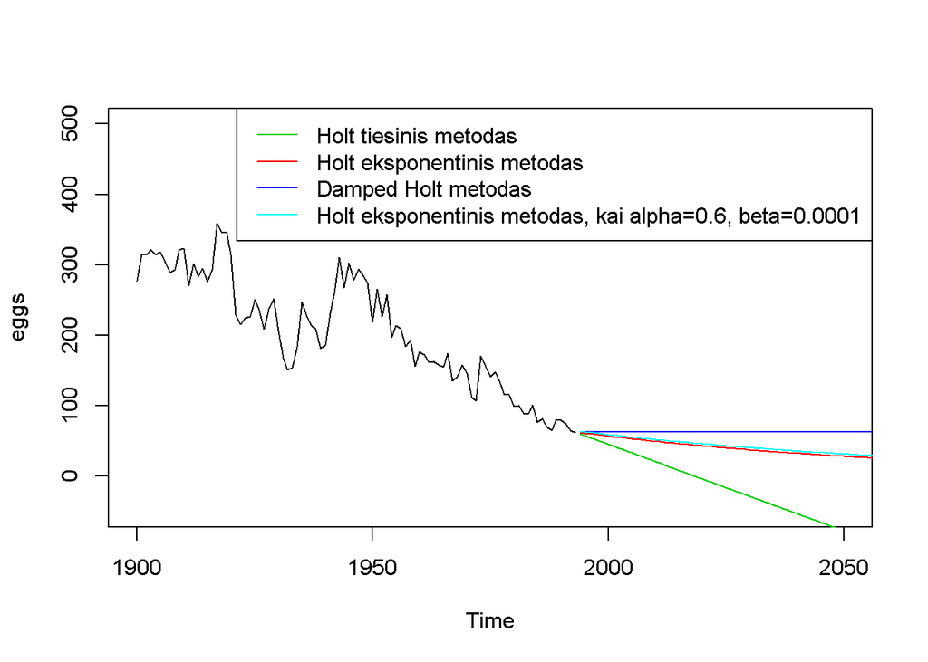

```r
plot(eggs, xlim=c(1900,2050), ylim=c(-50,500))
lines(fit1$mean, col=3)
lines(fit2$mean, col=2)
lines(fit3$mean, col=4)
lines(fit22$mean, col=5)
legend("topright",lty=1,lwd="1",col=c(3,2,4,5),legend=c("Holt tiesinis metodas","Holt eksponentinis metodas","Damped Holt metodas","Holt eksponentinis metodas, kai alpha=0.6, beta=0.0001"))
```

RMSE paklaidų rodikliai:

```r
kable(data.frame(tiesinis_metodas=accuracy(fit1)[2],eksponentinis_metodas=accuracy(fit2)[2],Damped_metodas=accuracy(fit3)[2],eksponentinis_a_0.6__b_0.0001=accuracy(fit22)[2]))
```

| tiesinis_metodas | eksponentinis_metodas | Damped_metodas | eksponentinis_a_0.6__b_0.0001 |
| --- | --- | --- | --- |
| 26.52594 | 26.39044 | 26.66184 | 26.93375 |

Holt eksponentinis glodinimas turėjo mažiausią paklaidą.

### Tikriname ar Holt eksponentinio glodinimo paklaidos yra baltasis triukšmas

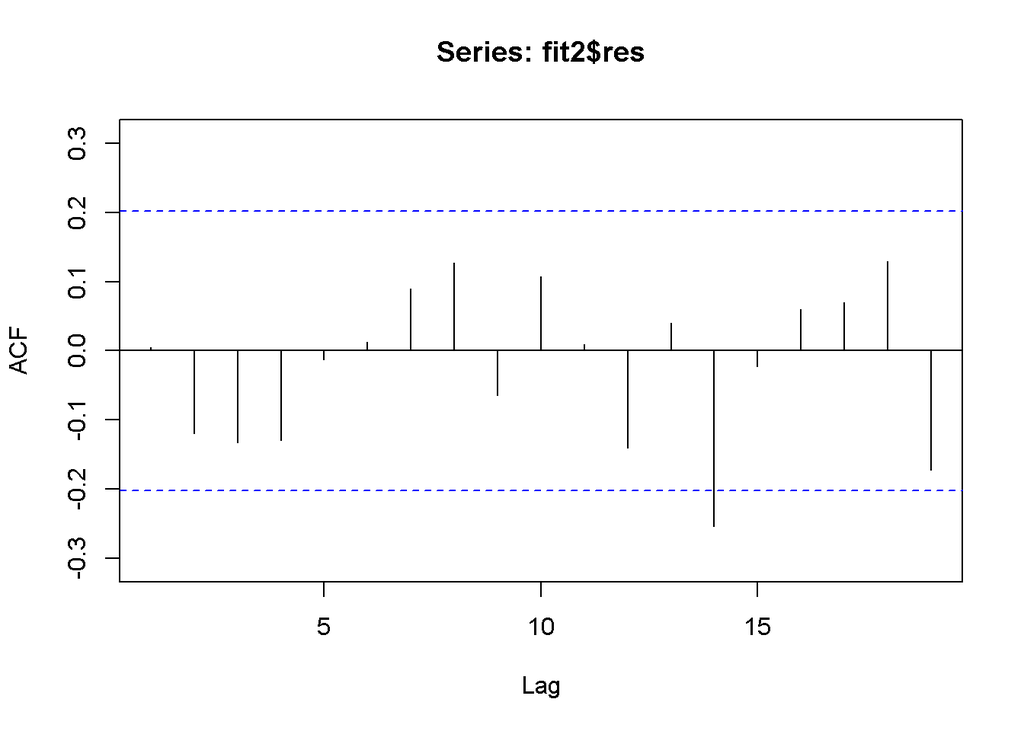

```r
Acf(fit2$res)
```

```r
shapiro.test(fit2$res)
```

```
##
##  Shapiro-Wilk normality test
##
## data:  fit2$res
## W = 0.9384, p-value = 0.0002475
```

```r
mean(fit2$res)
```

```
## [1] 0.003847893
```

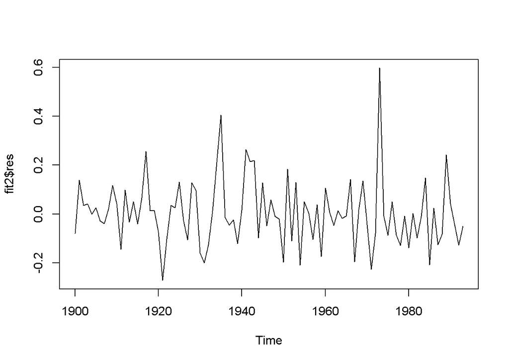

```r
plot(fit2$res)
```